# Phosphore_analyses

Jean Loup C

16/08/2019

# Packages

```r
require(lme4)
```

```r
require(ggplot2)
require(lattice)
require(reshape2)
require(RColorBrewer)
```

# WD et dataframe

```r
setwd("C:/Users/Madiba/Desktop/Phosphore2019/")

P <- read.table("releve_donnees_phosphore.csv", header=T, sep=",", dec = "," )
Fr <- read.table("releve_donnees_fruits.csv", header=T, sep=",", dec = "." )

# Verification des donnees
str(P)
```

```
## 'data.frame':    1548 obs. of  11 variables:
##  $ boite        : Factor w/ 129 levels "P1","P10","P100",..: 1 1 1 1 1 1 1 1 1 1 ...
##  $ ligne        : int  1 1 1 1 2 2 2 2 3 3 ...
##  $ colonne      : int  1 2 3 4 1 2 3 4 1 2 ...
##  $ concentration: num  1.2 0.15 0 1.65 0.9 1.05 0.75 1.35 1.5 0.45 ...
##  $ date_ponte   : Factor w/ 1 level "16/08/19": 1 1 1 1 1 1 1 1 1 1 ...
##  $ data_comptage: Factor w/ 2 levels "19/08/19","20/08/19": 1 1 1 1 1 1 1 1 1 1 ...
##  $ entree1      : int  0 0 0 0 1 0 0 0 5 8 ...
##  $ entree2      : int  0 0 0 0 1 0 0 0 5 8 ...
##  $ nb_oeufs     : int  0 0 0 0 1 0 0 0 5 8 ...
##  $ compteur     : Factor w/ 1 level "JL": 1 1 1 1 1 1 1 1 1 1 ...
##  $ test         : Factor w/ 1 level "OK": 1 1 1 1 1 1 1 1 1 1 ...
```

```r
str(Fr)
```

```
## 'data.frame':    240 obs. of  11 variables:
##  $ boite        : Factor w/ 20 levels "P171","P172",..: 1 1 1 1 1 1 1 1 1 1 ...
##  $ ligne        : int  1 1 1 1 2 2 2 2 3 3 ...
##  $ colonne      : int  1 2 3 4 1 2 3 4 1 2 ...
##  $ fruit        : Factor w/ 12 levels "Abricot","Cassis",..: 9 2 6 12 7 3 10 4 5 11 ...
##  $ date_ponte   : Factor w/ 1 level "16/08/19": 1 1 1 1 1 1 1 1 1 1 ...
##  $ date_comptage: Factor w/ 1 level "20/08/19": 1 1 1 1 1 1 1 1 1 1 ...
##  $ entree1      : int  19 20 23 6 0 20 10 2 2 7 ...
##  $ entree2      : int  19 20 23 6 0 20 10 2 2 7 ...
##  $ nb_oeufs     : int  19 20 23 6 0 20 10 2 2 7 ...
##  $ compteur     : Factor w/ 1 level "JL": 1 1 1 1 1 1 1 1 1 1 ...
##  $ test         : Factor w/ 1 level "OK": 1 1 1 1 1 1 1 1 1 1 ...
```

```r
P$obs <- as.factor(1:nrow(P))
Fr$obs <- as.factor(1:nrow(Fr))
```

# Plots

## Histogrammes du nombre d’oeuf par emplacement de boite de 12

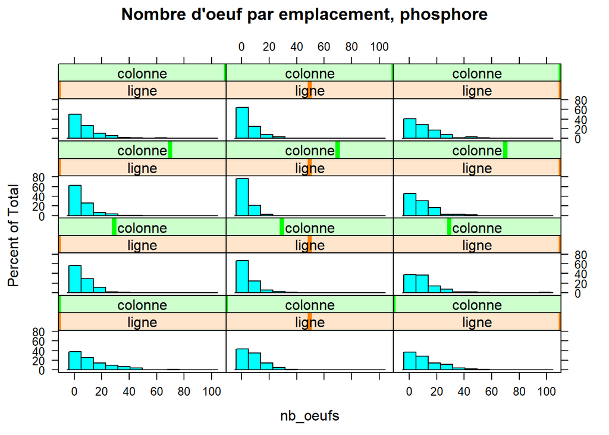

```r
histogram(~nb_oeufs|ligne*colonne, data=P, main="Nombre d'oeuf par emplacement, phosphore")
```

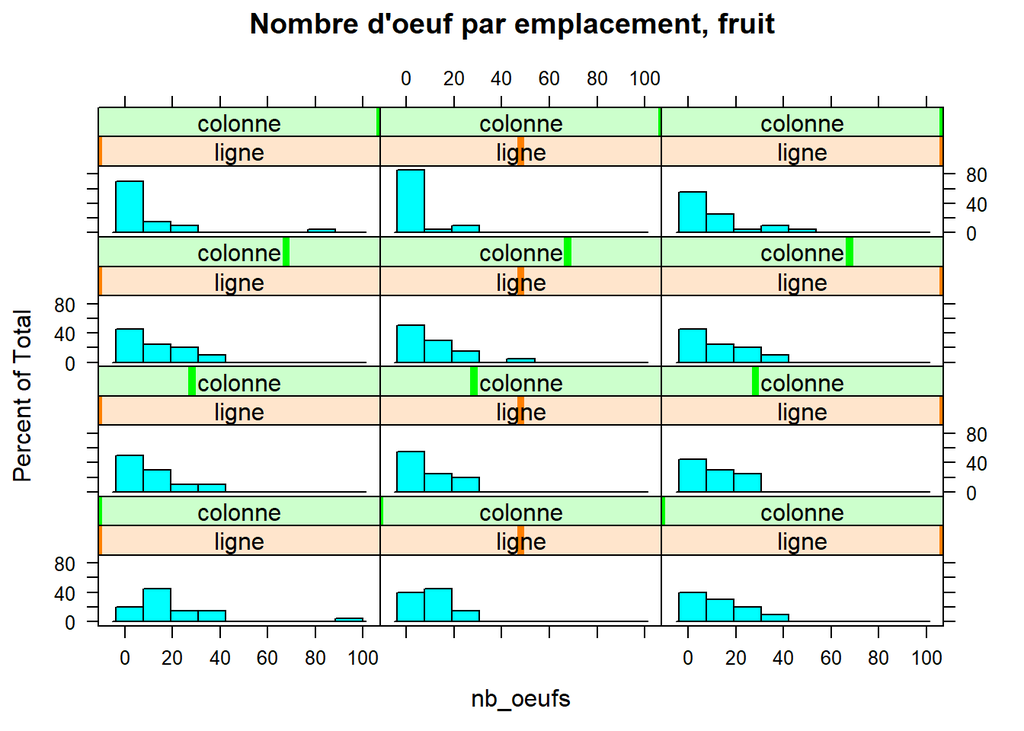

```r
histogram(~nb_oeufs|ligne*colonne, data=Fr, main="Nombre d'oeuf par emplacement, fruit")
```

## Nb_oeufs~concentration

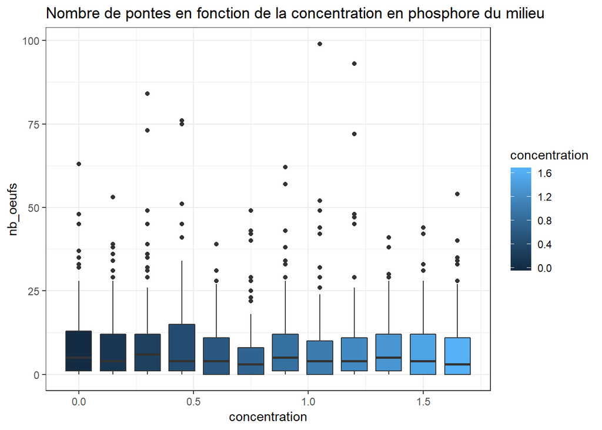

```r
ggplot(P, aes(x=concentration, y=nb_oeufs, group=concentration))+geom_boxplot(notch=F,aes(fill=concentration))+theme_bw()+ggtitle("Nombre de pontes en fonction de la concentration en phosphore du milieu")
```

On remarque ici que les moyennes de nombre de ponte en fonction de la concentration en phosphore restent sensiblement égales quelque soit la concentration en phosphore du milieu.

## Nb_oeufs~fruit

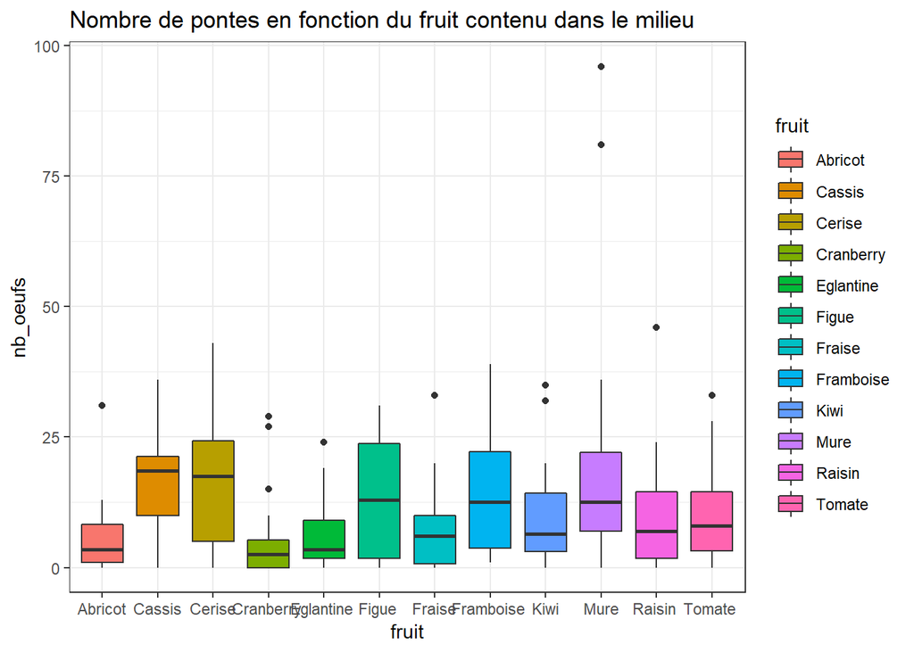

```r
ggplot(Fr, aes(x=fruit, y=nb_oeufs, group=fruit))+geom_boxplot(notch=F,aes(fill=fruit))+theme_bw()+ggtitle("Nombre de pontes en fonction du fruit contenu dans le milieu")
```

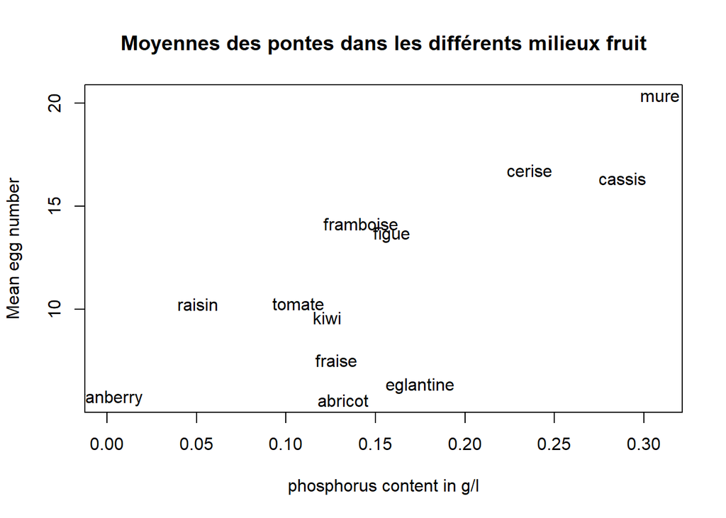

```r
fruit <- data.frame(tapply(Fr$nb_oeufs,Fr$fruit,mean))
fruit <- cbind(fruit, c("0.132","0.288","0.236","0","0.175","0.159","0.128","0.142","0.123","0.309","0.0506","0.107"))
fruit <- cbind(fruit, c("abricot","cassis","cerise","cranberry","eglantine","figue","fraise","framboise","kiwi","mure","raisin","tomate"))
colnames(fruit) <- c("mean","phosphorus", "fruits")
fruit$phosphorus <- as.numeric(as.character(fruit$phosphorus))

plot(fruit$mean~fruit$phosphorus, ylab="Mean egg number",xlab="phosphorus content in g/l", pch="", main="Moyennes des pontes dans les différents milieux fruit")
text(fruit$mean~fruit$phosphorus,labels=fruit$fruits)
```

On retrouve bien la tendance déjà découverte par Laure sur les fruits : les milieux de ponte préférés sont Cerise, Cassis et Mûre. On voit aussi que la Figue et la Framboise sont plus préférées que lors des tests précédents. Ces résultats prouvent que l’effet de préférence du phosphore dans les fruits peut êtrre détecté chez une lignée consanguine de laboratoire, comme chez une population sauvage.

# Analyses stats.

## Phosphore

### Test de corrélation nombre d’oeufs ~ concentration P

```r
cor.test(P$nb_oeufs, as.numeric(P$concentration), method="spearman")
```

```
##
##  Spearman's rank correlation rho
##
## data:  P$nb_oeufs and as.numeric(P$concentration)
## S = 641380868, p-value = 0.1411
## alternative hypothesis: true rho is not equal to 0
## sample estimates:
##         rho
## -0.03741987
```

### Concentrations

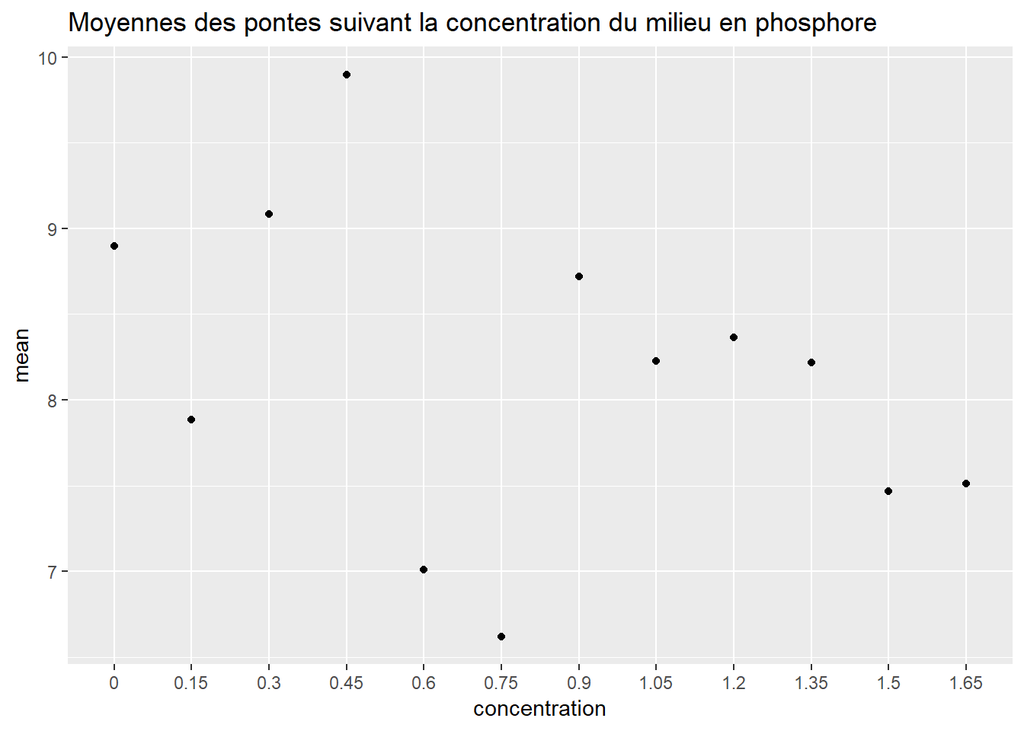

```r
concentration <- data.frame(tapply(P$nb_oeufs,P$concentration,mean, na.rm=T))
stdev <- tapply(P$nb_oeufs,P$concentration, sd, na.rm=T)
concentration <- cbind(concentration, c("0","0.15","0.3","0.45","0.6","0.75","0.9","1.05","1.2","1.35","1.5","1.65"))
colnames(concentration) <- c("mean","concentration")
ggplot(concentration, aes(x=concentration, y=mean))+geom_point()+ggtitle("Moyennes des pontes suivant la concentration du milieu en phosphore")
```

### GLM

```r
lm0 <- glmer(nb_oeufs~1+(1|boite)+(1|ligne:colonne) + (1|obs), data=P, family = poisson(link = "log"))
summary(lm0)
```

```
## Generalized linear mixed model fit by maximum likelihood (Laplace
##   Approximation) [glmerMod]
##  Family: poisson  ( log )
## Formula: nb_oeufs ~ 1 + (1 | boite) + (1 | ligne:colonne) + (1 | obs)
##    Data: P
##
##      AIC      BIC   logLik deviance df.resid
##   9398.2   9419.6  -4695.1   9390.2     1544
##
## Scaled residuals:
##      Min       1Q   Median       3Q      Max
## -1.24551 -0.60594 -0.01814  0.14595  0.73776
##
## Random effects:
##  Groups        Name        Variance Std.Dev.
##  obs           (Intercept) 1.4486   1.2036
##  boite         (Intercept) 0.6491   0.8057
##  ligne:colonne (Intercept) 0.2473   0.4973
## Number of obs: 1548, groups:  obs, 1548; boite, 129; ligne:colonne, 12
##
## Fixed effects:
##             Estimate Std. Error z value Pr(>|z|)
## (Intercept)   1.1915     0.1643   7.254 4.04e-13 ***
## ---
## Signif. codes:  0 '***' 0.001 '**' 0.01 '*' 0.05 '.' 0.1 ' ' 1
```

```r
lm1 <- glmer(nb_oeufs~concentration+(1|boite)+(1|ligne:colonne) + (1|obs), data=P, family = poisson(link = "log"))
summary(lm1)
```

```
## Generalized linear mixed model fit by maximum likelihood (Laplace
##   Approximation) [glmerMod]
##  Family: poisson  ( log )
## Formula: nb_oeufs ~ concentration + (1 | boite) + (1 | ligne:colonne) +
##     (1 | obs)
##    Data: P
##
##      AIC      BIC   logLik deviance df.resid
##   9397.3   9424.0  -4693.6   9387.3     1543
##
## Scaled residuals:
##      Min       1Q   Median       3Q      Max
## -1.23221 -0.59722 -0.01985  0.14394  0.75301
##
## Random effects:
##  Groups        Name        Variance Std.Dev.
##  obs           (Intercept) 1.4447   1.2020
##  boite         (Intercept) 0.6494   0.8059
##  ligne:colonne (Intercept) 0.2466   0.4966
## Number of obs: 1548, groups:  obs, 1548; boite, 129; ligne:colonne, 12
##
## Fixed effects:
##               Estimate Std. Error z value Pr(>|z|)
## (Intercept)    1.28738    0.17289   7.446 9.61e-14 ***
## concentration -0.11625    0.06673  -1.742   0.0815 .
## ---
## Signif. codes:  0 '***' 0.001 '**' 0.01 '*' 0.05 '.' 0.1 ' ' 1
##
## Correlation of Fixed Effects:
##             (Intr)
## concentratn -0.315
```

```r
anova(lm0,lm1,test="Chisq")
```

```
## Data: P
## Models:
## lm0: nb_oeufs ~ 1 + (1 | boite) + (1 | ligne:colonne) + (1 | obs)
## lm1: nb_oeufs ~ concentration + (1 | boite) + (1 | ligne:colonne) +
## lm1:     (1 | obs)
##     Df    AIC    BIC  logLik deviance  Chisq Chi Df Pr(>Chisq)
## lm0  4 9398.2 9419.6 -4695.1   9390.2
## lm1  5 9397.3 9424.0 -4693.6   9387.3 2.9426      1    0.08627 .
## ---
## Signif. codes:  0 '***' 0.001 '**' 0.01 '*' 0.05 '.' 0.1 ' ' 1
```

```r
P$concentrationsq <- P$concentration^2
lm2 <-  glmer(nb_oeufs~concentration+concentrationsq+(1|boite)+(1|ligne:colonne) + (1|obs), data=P, family = poisson(link = "log"))
summary(lm2)
```

```
## Generalized linear mixed model fit by maximum likelihood (Laplace
##   Approximation) [glmerMod]
##  Family: poisson  ( log )
## Formula: nb_oeufs ~ concentration + concentrationsq + (1 | boite) + (1 |
##     ligne:colonne) + (1 | obs)
##    Data: P
##
##      AIC      BIC   logLik deviance df.resid
##   9399.1   9431.1  -4693.5   9387.1     1542
##
## Scaled residuals:
##      Min       1Q   Median       3Q      Max
## -1.23532 -0.59661 -0.01786  0.14425  0.75643
##
## Random effects:
##  Groups        Name        Variance Std.Dev.
##  obs           (Intercept) 1.4442   1.2018
##  boite         (Intercept) 0.6496   0.8060
##  ligne:colonne (Intercept) 0.2467   0.4967
## Number of obs: 1548, groups:  obs, 1548; boite, 129; ligne:colonne, 12
##
## Fixed effects:
##                 Estimate Std. Error z value Pr(>|z|)
## (Intercept)      1.31562    0.18270   7.201 5.98e-13 ***
## concentration   -0.23041    0.24790  -0.929    0.353
## concentrationsq  0.06955    0.14532   0.479    0.632
## ---
## Signif. codes:  0 '***' 0.001 '**' 0.01 '*' 0.05 '.' 0.1 ' ' 1
##
## Correlation of Fixed Effects:
##             (Intr) concntrtn
## concentratn -0.391
## concntrtnsq  0.323 -0.963
```

```r
anova(lm1,lm2,test="Chisq")
```

```
## Data: P
## Models:
## lm1: nb_oeufs ~ concentration + (1 | boite) + (1 | ligne:colonne) +
## lm1:     (1 | obs)
## lm2: nb_oeufs ~ concentration + concentrationsq + (1 | boite) + (1 |
## lm2:     ligne:colonne) + (1 | obs)
##     Df    AIC    BIC  logLik deviance  Chisq Chi Df Pr(>Chisq)
## lm1  5 9397.3 9424.0 -4693.6   9387.3
## lm2  6 9399.1 9431.1 -4693.5   9387.1 0.2214      1      0.638
```

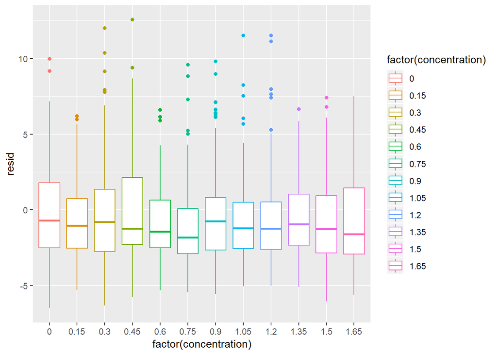

```r
lm4 <- glm(nb_oeufs~ligne:colonne +boite, data=P, family = poisson(link = "log"))
P$resid <- residuals(lm4)

ggplot(P, aes(x=factor(concentration), col=factor(concentration), y=resid))+geom_boxplot()
```

#### Effet de la position

```r
lm4 <- glmer(nb_oeufs~(1|ligne:colonne)+(1|boite), data=P, family = poisson(link = "log"))
anova(lm0,lm4, test="Chisq")
```

```
## Data: P
## Models:
## lm4: nb_oeufs ~ (1 | ligne:colonne) + (1 | boite)
## lm0: nb_oeufs ~ 1 + (1 | boite) + (1 | ligne:colonne) + (1 | obs)
##     Df     AIC     BIC  logLik deviance  Chisq Chi Df Pr(>Chisq)
## lm4  3 16727.0 16743.0 -8360.5  16721.0
## lm0  4  9398.2  9419.6 -4695.1   9390.2 7330.7      1  < 2.2e-16 ***
## ---
## Signif. codes:  0 '***' 0.001 '**' 0.01 '*' 0.05 '.' 0.1 ' ' 1
```

```r
ranef(lm4)
```

[output not shown]

[output cut: 93 more lines]

```
##     (Intercept)
## 1:1  0.55913133
## 1:2 -0.19978253
## 1:3 -0.29571505
## 1:4  0.33086261
## 2:1  0.07824481
## 2:2 -0.46257788
## 2:3 -0.95712146
## 2:4 -0.36515671
## 3:1  0.54409519
## 3:2  0.36040252
## 3:3  0.11328890
## 3:4  0.37485268
##
## with conditional variances for "boite" "ligne:colonne"
```

```r
summary(lm4)
```

```
## Generalized linear mixed model fit by maximum likelihood (Laplace
##   Approximation) [glmerMod]
##  Family: poisson  ( log )
## Formula: nb_oeufs ~ (1 | ligne:colonne) + (1 | boite)
##    Data: P
##
##      AIC      BIC   logLik deviance df.resid
##  16727.0  16743.0  -8360.5  16721.0     1545
##
## Scaled residuals:
##     Min      1Q  Median      3Q     Max
## -5.1089 -1.8474 -0.9256  1.1219 13.9220
##
## Random effects:
##  Groups        Name        Variance Std.Dev.
##  boite         (Intercept) 0.5530   0.7437
##  ligne:colonne (Intercept) 0.2046   0.4523
## Number of obs: 1548, groups:  boite, 129; ligne:colonne, 12
##
## Fixed effects:
##             Estimate Std. Error z value Pr(>|z|)
## (Intercept)   1.7851     0.1466   12.18   <2e-16 ***
## ---
## Signif. codes:  0 '***' 0.001 '**' 0.01 '*' 0.05 '.' 0.1 ' ' 1
```

Il pourrait y avoir un effet d’autocorrélation spatiale à tester ici.

### Pontes moyennes par position

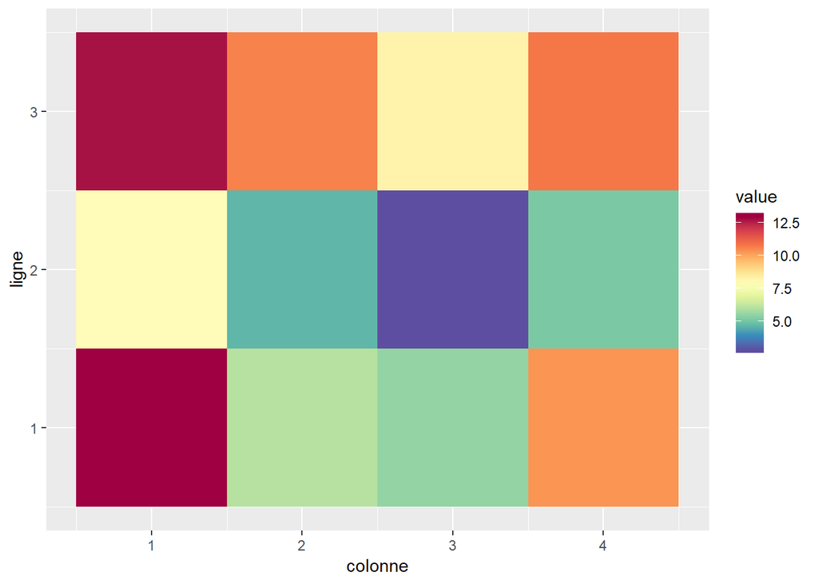

```r
spatial_mean <-(tapply(P$nb_oeufs, list(colonne=P$colonne, ligne=P$ligne), mean))
spatial_mean_melted <- melt(spatial_mean)
hm.palette <- colorRampPalette(rev(brewer.pal(11, 'Spectral')), space='Lab')
ggplot(spatial_mean_melted, aes(x = colonne, y = ligne, fill = value)) +
  geom_tile()+
  scale_fill_gradientn(colours = hm.palette(100))
```

Les moyennes de ontes sont largement plus élevées sur les lignes externes des boites et notamment dans les colonnes de gauche.

## Fruits

### Corrélation phosphore

```r
cor.test(fruit$mean, as.numeric(fruit$phosphorus), method="spearman")
```

```
##
##  Spearman's rank correlation rho
##
## data:  fruit$mean and as.numeric(fruit$phosphorus)
## S = 102, p-value = 0.02795
## alternative hypothesis: true rho is not equal to 0
## sample estimates:
##       rho
## 0.6433566
```

On remarque une corrélation positive entre les moyennnes des pontes sur milieux fruit et leur concentration en phosphore.

### GLM

```r
lm0 <- glmer(nb_oeufs~1+(1|boite), data=Fr, family = poisson(link = "log"))
lm1 <- glmer(nb_oeufs~fruit+(1|boite), data=Fr, family = poisson(link = "log"))
lm2 <- glm(nb_oeufs~fruit, data=Fr, family = poisson(link = "log"))

anova(lm0,lm1,test="Chisq")
```

```
## Data: Fr
## Models:
## lm0: nb_oeufs ~ 1 + (1 | boite)
## lm1: nb_oeufs ~ fruit + (1 | boite)
##     Df    AIC    BIC  logLik deviance  Chisq Chi Df Pr(>Chisq)
## lm0  2 2953.7 2960.7 -1474.8   2949.7
## lm1 13 2523.4 2568.7 -1248.7   2497.4 452.27     11  < 2.2e-16 ***
## ---
## Signif. codes:  0 '***' 0.001 '**' 0.01 '*' 0.05 '.' 0.1 ' ' 1
```

```r
anova(lm1,lm2,test="Chisq")
```

```
## Data: Fr
## Models:
## lm2: nb_oeufs ~ fruit
## lm1: nb_oeufs ~ fruit + (1 | boite)
##     Df    AIC    BIC  logLik deviance Chisq Chi Df Pr(>Chisq)
## lm2 12 3366.4 3408.2 -1671.2   3342.4
## lm1 13 2523.4 2568.7 -1248.7   2497.4   845      1  < 2.2e-16 ***
## ---
## Signif. codes:  0 '***' 0.001 '**' 0.01 '*' 0.05 '.' 0.1 ' ' 1
```

La tendance observée sur les boxplots des pontes sur milieux fruits est confirmée. Les fruits les plus concentrés en phosphore sont préférés par les D.suzuki.

### Pontes moyennes par position

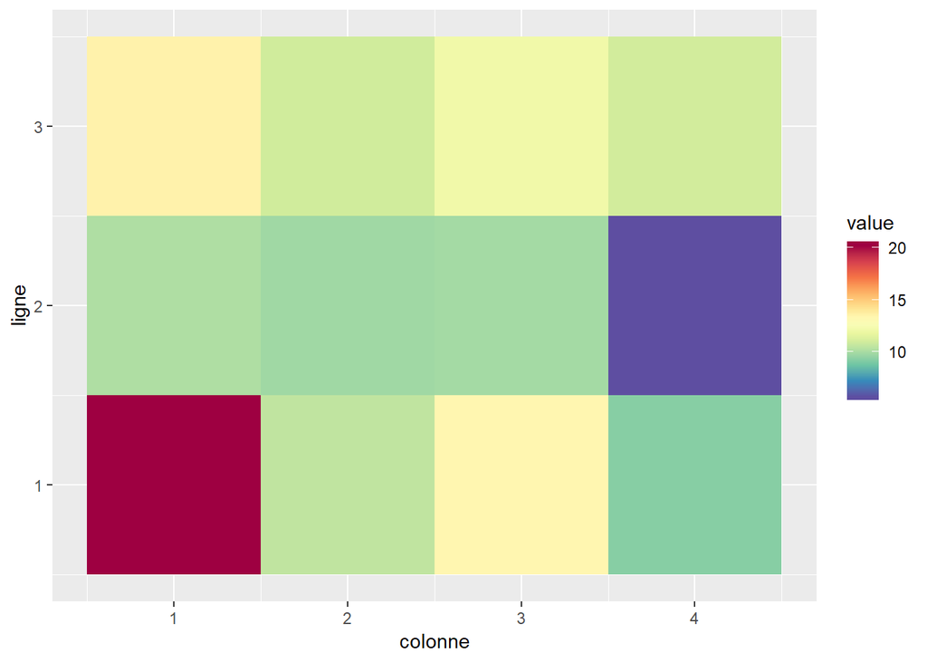

```r
spatial_mean_fr <-(tapply(Fr$nb_oeufs, list(colonne=Fr$colonne, ligne=Fr$ligne), mean))
spatial_mean_fr_melted <- melt(spatial_mean_fr)
ggplot(spatial_mean_fr_melted, aes(x = colonne, y = ligne, fill = value)) +
  geom_tile()+
  scale_fill_gradientn(colours = hm.palette(100))
```

Pour les boîtes de fruit, on observe des pontes moyennes largement plus élevées dans le coin bas gauche des boîtes. Il faudrait donc également essayer de fitter un modèle prenant en compte l’impact de la position des milieux sur les données fruits. On retrouve une moyenne de ponte élevée dans le coin bas gauche de boites de milieux phosphore et fruit. s